# Where are the Starbuck’s At?

Will Jones

May 11, 2015

This project examines correlations between the number of Starbuck’s locations in an area with the rate of poverty in an area. For the locations, this project examines census tracts in Los Angeles County.

More generally, this project explored scraping locations from Google’s Places API to determine the number of locations near census tracts. This project also discusses analyizing this type of data, which has really strong spatial correlation between data points. In analyizing the data, I used a permuatation test with Monte Carlo sampling and bootstrapping to test the significance of differences in rates of Starbuck’s per 1,000 population in low and high poverty areas and get confidence intervals for the average rates.

This anaylsis could easily be adapted to other scenarios (that are probably more interesting, to be honest.) For example, how are medical marijuana clinics or payday loan businesses correlated with povery in surrounding areas? How does this vary between different cities?

## Getting the Data

Census data and shapefiles can be downloaded, but the location data for the Starbuck’s location needs to be scraped from Google.

### Census Data

Census data is provided by the 2010 census for estimates of population and ethnic makeup, while we use American Community Survey five-year estimates for median income and poverty level. The csv files were compiled and downloaded on [Social Explorer](http://www.socialexplorer.com).

Here are some histograms of the basic demographic data:

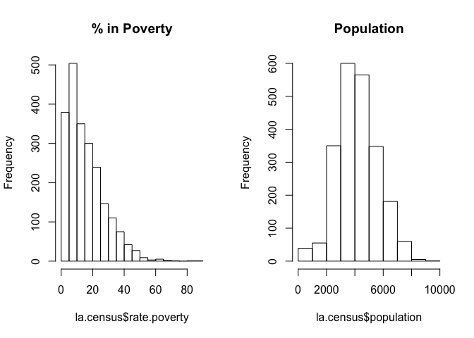

### Los Angeles County Shapefiles

The shapefiles were acquired from the [County of Los Angeles’ Open Data Portal](https://data.lacounty.gov/Geospatial/Census-Tracts-2010/ay2y-b9rg).

### Scrapping the Location Data

Now that we have a selection of census tracts to examine, we need to find how many Starbucks locations are nearby each. To get all the relevant locations in the area, we can do a series of searches on Google around specially chosen points.

[Google’s Places API](https://developers.google.com/places/webservice/) allows developers to send HTTP request for “Radar Searches,” which take a lat/long location, a radius and search query and returns up to 200 locations in the given radius that match the query.

Thus, if we can cover all of LA County with a series of Radar Searches, we can find all the locations of all Starbuck’s in the area. It turns out we can accomplish this with just 24 radar searches, each with radii of 13 kilometers. (The maximum radius is 50km, but this increases the likelihood that we will miss locations, for the API call only returns up to 200 locations at once.)

Below is a plot showing the arrangement of all the radar searches. (The function used here to draw circles was adapted from code written by Gregoire Vincke, in a [Stack Overflow answer](http://stackoverflow.com/a/29133886/4645559).)

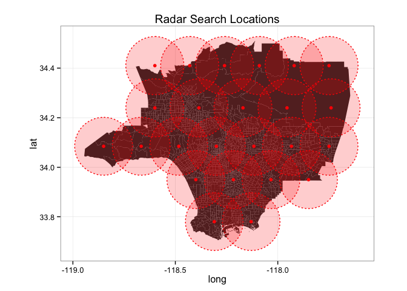

The locations have been saved as a file and are just loaded from that file in this document. For those who are interested, though, the code used to scrape the location data is present in the RMD file, with the portions that actually execute the search commented out. (In order to make use of the code though, you will need to get your own API key from Google.)

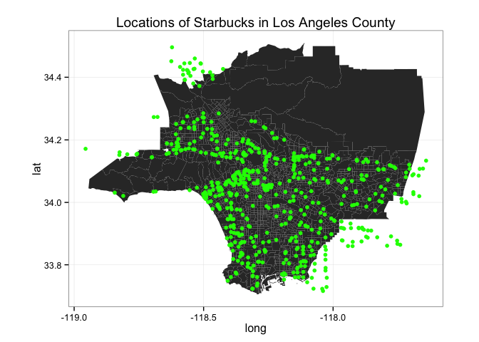

Notice there are some areas with no locations. To the north is Angeles National Forest, and the western stretch is Santa Monica Mountains Recreational Area. In some areas, that are likely less populated, the locations seem to align with whatever freeways are nearby.

From these locations we can calculate the number of Starbuck’s nearby for each census tract. We will consider a Starbuck’s location nearby if it is within 2 kilometers of the border of the census tract.

The results of this data manipulation are also saved as an R data dump, because of how long they took to calculate. Once again, the code to make the calculations can be found in the RMD file, with the lines that execute the calculate commented out. (Please take a moment of silence to mourn the many hours I lost to figuring out how to draw a circle on a spherical Earth and then detect whether that circle intersected with a polygon that also exists on a spherical Earth.)

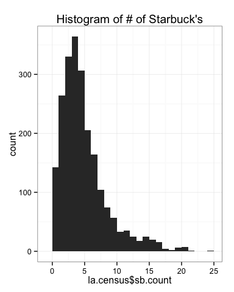

## Exploring the Data

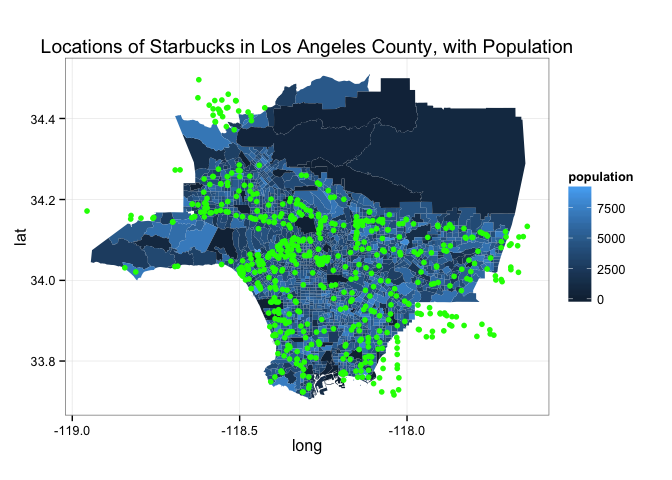

```
## Source: local data frame [2,203 x 3]
##
##    population sb.count sb.per.1000
## 1           1        9  9000.00000
## 2           4       10  2500.00000
## 3          14       24  1714.28571
## 4           4        3   750.00000
## 5           8        3   375.00000
## 6          59       13   220.33898
## 7          22        4   181.81818
## 8          20        3   150.00000
## 9          61        6    98.36066
## 10         31        2    64.51613
## ..        ...      ...         ...
```

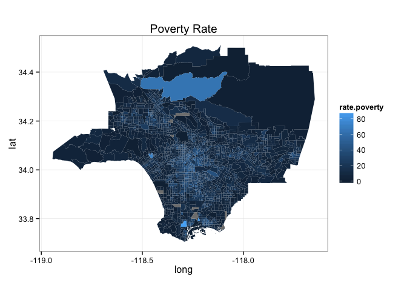

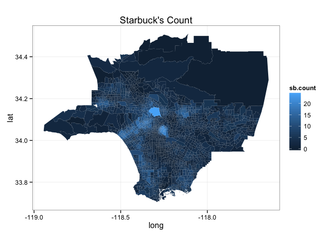

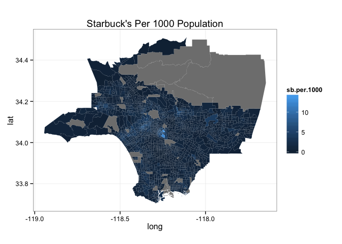

## Fitting a Model

Now we need to choose a model for this data. We could try a Poisson model, as our response variable is a count, but the variance of the data is greater than the mean, and thus our data is “overdispersed.”

```r
c(mean(la.census$sb.count), var(la.census$sb.count))
```

```
## [1]  4.375851 12.947682
```

To correct for this, we will model the data with a quasi-Poisson family. We are filtering out the tracts with low population, and then offsetting by population, so that it is taken into account in the model.

```r
model <- la.census %>% filter(population > 1000) %>%
  glm(sb.count ~ 1, data = ., offset=log(population),
      family=quasipoisson)
# The average number of Starbucks per 1000 people
exp(model$coefficients)*1000
```

```
## (Intercept)
##    1.027974
```

### Starbuck’s Counts and Poverty

Now here is the question: Are the distributions of Starbuck’s counts, taking into account population, statistcally different depending on the level of poverty?

```r
la.census %<>% mutate(poverty = rate.poverty > 40)

modelA <- la.census %>% filter(population > 1000 & poverty) %>%
  glm(sb.count ~ 1, data = ., offset=log(population),
      family=quasipoisson)
# The average number of Starbucks per 1000 people
exp(modelA$coefficients)*1000
```

```
## (Intercept)
##    1.280697
```

```r
modelB <- la.census %>% filter(population > 1000 & !poverty) %>%
  glm(sb.count ~ 1, data = ., offset=log(population),
      family=quasipoisson)
# The average number of Starbucks per 1000 people
exp(modelB$coefficients)*1000
```

```
## (Intercept)
##    1.018293
```

If we split up the census tracts by whether their povery rate is greater than 40%, we find that the intercept coefficient is fairly different, suggesting there are different rates in the two groups.

We could try a doing a model with `glm` of `sb.count ~ rate.poverty`, but our Starbuck’s location counts are **not independent** at all; the number of Starbuck’s near one census tract is highly correlated with the count for a neighboring census tract.

Essentially our effective sample size is a smaller than the number of census tracts we observed, because the high correlation means that any given census tract provides little additional information.

Instead, we can use a permutation test, which does not make any assumptions about the distribution the data comes from and will preserve the spatial relationships between census tracts.

For the quasipoisson model we computed for this data, given the intercept term $I$, let the average number of Starbuck’s locations per 1,000 people is $\lambda = 1000 \cdot exp(I).$ Let $\lambda_A$ be the $\lambda$ value for the census tracts that have a poverty rate greater than 40% and $\lambda_B$ be the value for the rest of the census tracts. Then our hypotheses will be:

- $H_0: \lambda_A - \lambda_B = 0$
- $H_A: \lambda_A - \lambda_B \neq 0$

Our test statistical that we observed from our sample is:

```r
T_obs <- exp(modelA$coefficients)*1000 - exp(modelB$coefficients)*1000
T_obs
```

```
## (Intercept)
##   0.2624036
```

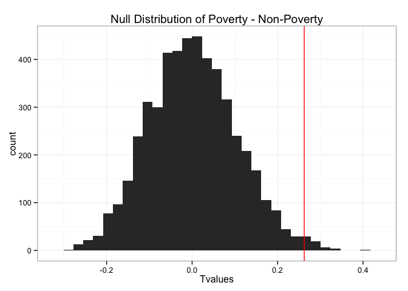

The probability of getting a value of $T$ as likely or less likely than our $T_{obs}$ from the null permutation distribution is

```r
2 * (sum(Tvalues >= T_obs) + 1)/(iterations+1)
```

```
## [1] 0.01879624
```

Thus, we can say with a confidence of 98% there is a statistically significant difference between the distribution of Starbuck’s counts in poorer and wealthier areas.

We can construct confidence intervals for these values using Bootstrapping, a method that in similar in principle to what we just did. Bootstrapping estimates the distribution of a statistic about a set of data by calculating that statistic on a large number of samples from the data set, each of which are the same size as the original data but sampled with replacement. From this approximated distribution, we can then get the 95% confidence intervals by finding the quantiles for 0.025 and 0.975.

```r
bootstrap.CI(5000)
```

```
## [[1]]
##      2.5%     97.5%
## 0.9862144 1.6166196
##
## [[2]]
##      2.5%     97.5%
## 0.9805457 1.0574135
```

## Conclusions

I found that there the rate of Starbuck’s per 1,000 people in high-poverty census tracts is higher than the low-poverty rate in Los Angeles County. In some ways, I find this counter-intuitive; why would Starbuck’s locations be more numerous where more of the population in the area probably cannot afford to buy a $4.00 lattés all the time?

Either my intuition is wrong, or there is something missing from my model. One thing I did not account for is the population densities of census tracts. It is possible that Starbuck’s are simply spread out geographically such that areas with more people will naturally have more Starbuck’s per 1,000 people.

It’s important to note that these results are not generalizable outside of Los Angeles County; all the data examined was limited to that area.

## Analysis Round 2

This is after the due date, but I wanted to follow up on the land area issue.

I mentioned in my previous conclusions from my first analysis that the model I used may not be accurate because I failed to account for the difference in size between census tracts.

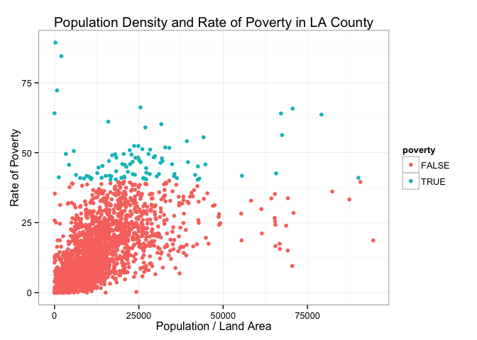

There clearly is a relationship between the rate of poverty and population density. Furthermore, the average population density for what we labelled as higher poverty areas is clearly higher than that of low poverty areas. So the assumptions I made in speculating that a model that took into account land area are true.

Below I have created a model that takes into account the amount of land area (so excluding parts that are water) in a census tract. From it we can compute a new statistic, the average number of Starbuck’s per 1,000 population per square mile.

```r
modelA <- la.census %>% filter(population > 1000 & poverty) %>%
  glm(sb.count ~ 1, data = ., offset=log(population / area.land),
      family=quasipoisson)
# The average number of Starbucks per 1000 people per sq. mile
exp(modelA$coefficients)*1000
```

```
## (Intercept)
##   0.1819664
```

```r
modelB <- la.census %>% filter(population > 1000 & !poverty) %>%
  glm(sb.count ~ 1, data = ., offset=log(population / area.land),
      family=quasipoisson)
# The average number of Starbucks per 1000 people per sq. mile
exp(modelB$coefficients)*1000
```

```
## (Intercept)
##   0.3246997
```

Here, we get what seems to be a clearly lower rate for high poverty census tracts, which aligns with my earlier intuition that the rate should be lower for census tracts with greater poverty levels.

As before, we can use a permutation test to determine if these two values have a difference that is statistically significant.

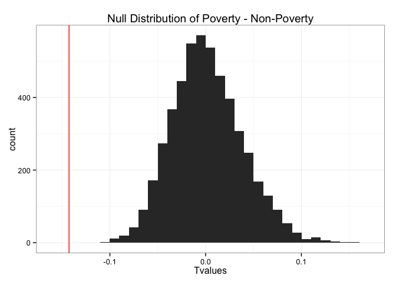

The probability of getting a value of $T$ as likely or less likely than our $T_{obs}$ from the null permutation distribution is

```r
2 * (sum(Tvalues <= T_obs) + 1)/(iterations+1)
```

```
## [1] 0.00039992
```

Thus, we can say with 99.96% confidence that the two rates are different.

Again, we can find confidence intervals for these rates using bootstrapping.

```r
bootstrap.CI(5000)
```

```
## [[1]]
##      2.5%     97.5%
## 0.1420536 0.2254875
##
## [[2]]
##      2.5%     97.5%
## 0.3101007 0.3400189
```

Thus, with our analyis taking into account for finds that the average number of Starbuck’s per 1,000 population per square mile in census tracts with high poverty is 0.18 (95% CI [0.14, 0.23]) and in census tracts with low poverty is 0.32 (95% CI [0.31, 0.34]).